# Modele liniowe - Sprawozdanie 4

Błażej Wiórek

## Zadanie 1 - Wprowadzenie do problemu

Chcemy zbadać związek pomiędzy liczbą wizyt w gabinecie lekarskim (zmienna zależna - ofp) i zmiennymi niezależnymi opisującymi pacjenta. Zmienne objaśniające mają następującą postać:

- hosp - liczba pobytów w szpitalu
- health - zmienna opisująca subiektywne odczucie pacjenta o jego zdrowiu
- numchron - liczba przewlekłych stanów chorobowych
- gender - płeć
- school - liczba lat edukacji
- privins - indykator opisujący to czy pacjent ma dodatkowe prywatne ubezpeczenie zdrowotne

## Zadanie 2 - Wstępna analiza

**a)**: Narysuj histogram zmiennej “ofp”. Czy wykres wskazuje na obecność zjawiska nadmiernej dyspersji i/lub inflacji w zerze?

**Inflacja w zerze**: Przedstawiony histogram sugeruje, że występuje zjawisko inflacji w zerze jako, że znaczna część obserwacji jest skupiona właśnie w tym punkcie.

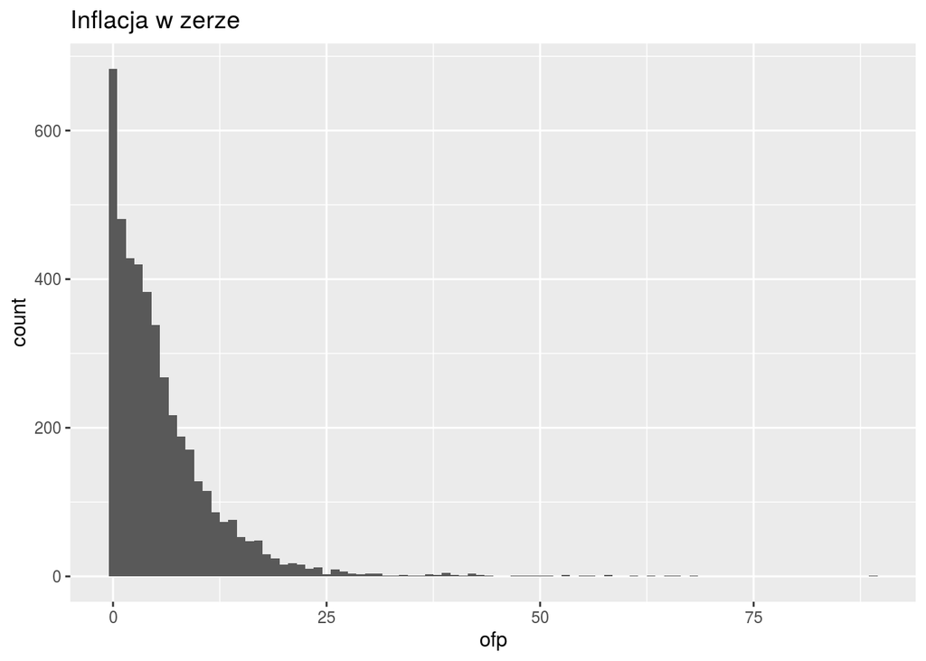

Warto dokładnie określić liczbe elementów zerowych:

```
##   n_zero_elements
## 1             683
```

**Nadmierna dyspersja**: Chcąc modelować $ofp$ za pomocą regresji Poissona należy założyć, że $\mathbb{E}[ofp] = Var[ofp] = \mu$. Wynika z tego, że jeśli chcemy sprawdzić czy występuje zjawisko nadmiernej dyspersji, podstawową procedurą jest porównanie wspomnianych statystyk.

```
## [1] "Mean:  5.77439854743532 Variance:  45.6871174020773"
```

Nie trudno zauważyć, że $Var[ofp] >> \mathbb{E}[ofp]$.

**b)**: Ze względu na znaczącą liczbę zer wprowadź zmienną pomocniczą $f(ofp)=log(ofp+0.5)$ dzięki której łatwiej będzie zbadać wzajemne zależności pomiędzy “ofp” i regresorami.

Zaproponowana tansformacja ma na celu przybliżenie rozkładu zmiennej objaśnianej do rozkładu normalnego.

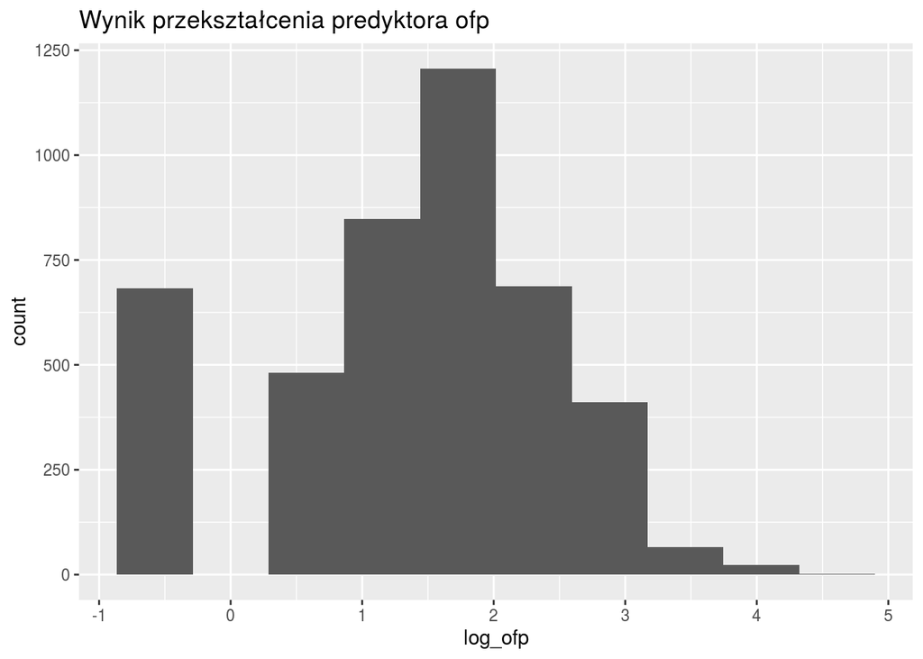

**c)**: Narysuj dla każdego regresora osobno na jednym rysunku boxploty dla $f(ofp)$ w rozbiciu ze względu na przyjmowane wartości przez dany regresor. Jeżeli dla danej wartości regresora będzie mało obserwacji, pogrupuj wartości regresora i wykonaj boxplot dla pogrupowanych wartości.

Postanowiłem rozpocząć od sprawdzenia, które zmienne można poddać procedurze łączenia poziomów odpowiadających niewielkiej części populacji.

```
## Rows: 4,406
## Columns: 8
## $ ofp      <int> 5, 1, 13, 16, 3, 17, 9, 3, 1, 0, 0, 44, 2, 1, 19, 19, 0, 3, …
## $ hosp     <ord> 1, 0, 3, 1, 0, 0, 0, 0, 0, 0, 0, 1, 0, 0, 1, 0, 0, 0, 0, 0, …
## $ health   <fct> average, average, poor, poor, average, poor, average, averag…
## $ numchron <ord> 2, 2, 4, 2, 2, 5, 0, 0, 0, 0, 1, 5, 1, 1, 1, 0, 1, 2, 3, 4, …
## $ gender   <fct> male, female, female, male, female, female, female, female, …
## $ school   <ord> 6, 10, 10, 3, 6, 7, 8, 8, 8, 8, 8, 15, 8, 8, 12, 8, 8, 8, 10…
## $ privins  <fct> yes, yes, no, yes, yes, no, yes, yes, yes, yes, yes, yes, no…
## $ log_ofp  <dbl> 1.7047481, 0.4054651, 2.6026897, 2.8033604, 1.2527630, 2.862…
```

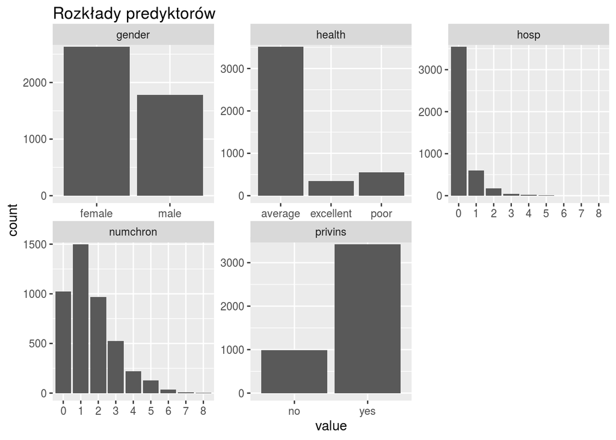

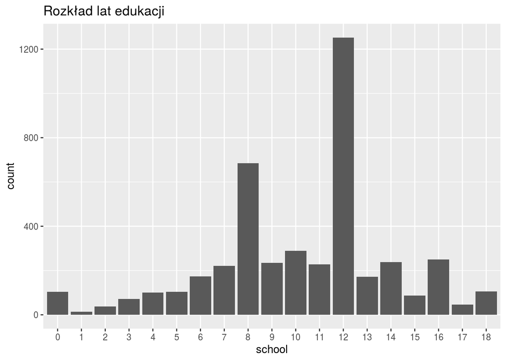

Grupowanie wartości regresora ma na celu zmniejszenie liczby niepotrzebnych współczynników modelu. Na podstawie przedstawionych wykresów można wywnioskować, że warto zgrupować np. numchron do postaci: $\{0, 1, ..., 5, 6+\}$ oraz liczby pobytów w szpitalu do postaci: $\{0, 1, 2, 3+\}$.

```
## Rows: 4,406
## Columns: 8
## $ ofp      <int> 5, 1, 13, 16, 3, 17, 9, 3, 1, 0, 0, 44, 2, 1, 19, 19, 0, 3, …
## $ hosp     <fct> 1, 0, 3+, 1, 0, 0, 0, 0, 0, 0, 0, 1, 0, 0, 1, 0, 0, 0, 0, 0,…
## $ health   <fct> average, average, poor, poor, average, poor, average, averag…
## $ numchron <ord> 2, 2, 4, 2, 2, 5, 0, 0, 0, 0, 1, 5, 1, 1, 1, 0, 1, 2, 3, 4, …
## $ gender   <fct> male, female, female, male, female, female, female, female, …
## $ school   <int> 6, 10, 10, 3, 6, 7, 8, 8, 8, 8, 8, 15, 8, 8, 12, 8, 8, 8, 10…
## $ privins  <fct> yes, yes, no, yes, yes, no, yes, yes, yes, yes, yes, yes, no…
## $ log_ofp  <dbl> 1.7047481, 0.4054651, 2.6026897, 2.8033604, 1.2527630, 2.862…
```

Po zgrupowaniu danych warto spojrzeć na wspomniane boxploty w celu określenia które zmienne mogą być związane ze zmienną objaśnianą.

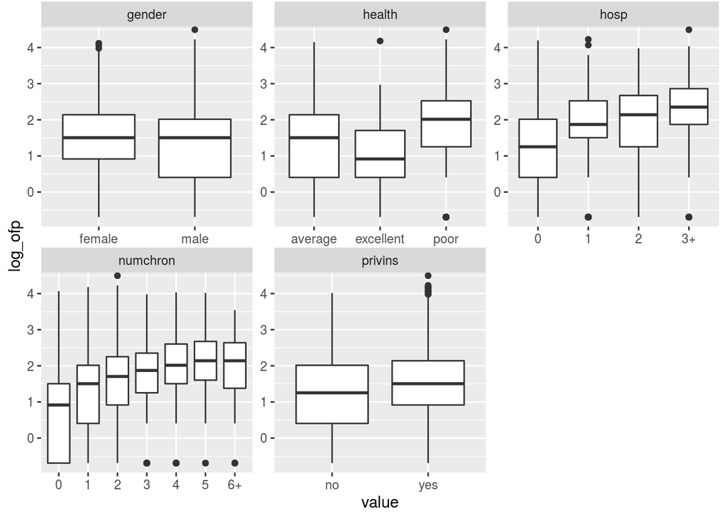

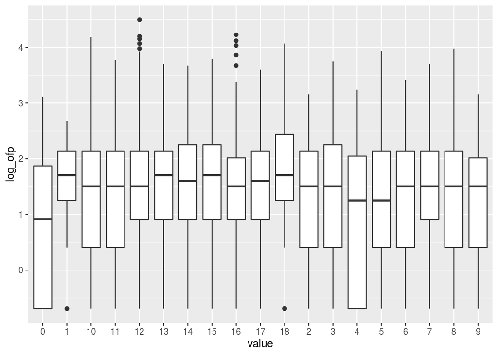

Wygląda na to, że wszystkie predyktory z wyjątkiem liczba lat edukacji są w mniejszym lub większym stopniu związane ze zmienną objaśnianą.

- gender - mediana dla kobiet i mężczyzn jest niemal identyczna. Mimo to widoczne jest, że u mężczyzn liczba wizyt charakteryzuje się znacznie większą wariancją. Można to próbować tłumaczyć tym, że część mężczyzn idzie do lekarza w ostateczności, podczas gdy kobiety mają tutaj bardziej zrównoważone podejście.
- health - obserwacje sugerują dość oczywistą zależność tzn. osoby czujące się dobrze nie chodzą do lekarza, podczas gdy osoby określające swój stan zdrowia jako zły chodzą częściej.
- hosp - kolejna dość oczywista zależność jako, że zgodnie z oczekiwaniami osoby, które często bywają w szpitalu częściej odbywają wizyty w gabinecie. Może to być np. spowodowane konsultacjami po wypisaniu ze szpitala.
- numchron - podobnie jak w przypadku innych predyktorów, im więcej przewlekłych stanów chorobowych tym więcej wizyt u lekarza.

## Zadanie 3 - Dopasowanie modeli

Zadanie polega na dopasowaniu i porównaniu następujących modeli:

- Model Poissona
- Model ujemny dwumianowy
- Model ZIPR
- Model ZINBR
- Model Poissona z barierą
- Model ujemny dwumianowy z barierą

Powyższe zestawienie to (z wyłączeniem regresji Poissona) zbiór modeli mających na celu uwzględnienie zjawiska nadmiernej inflacji i/lub zjawiska nadmiernej dyspersji. Celem zadania jest próba uzyskania minimalnego ale wystarczającego modelu w każdym przedstawionym przypadku. Podstawowym narzędziem do redukcji liczby parametrów będzie wynik funkcji summary() dla modelu pełnego, a następnie skorzystanie z Likelihood-Ratio test dla modelu zredukowanego i pełnego. Redukcja zostanie przeprowadzona tylko jeśli będą ku temu odpowiednie przesłanki.

**Model Poissona**

Klasyczny model związany z regresji Poissona w którym:
$$\begin{gather*}
\mathbb{E}[Y] = \mu \\
Var[Y] = \mu
\end{gather*}$$

Model ten nie uwzględnia ani zjawiska nadmiernej dyspersji ani inflacji w zerze. Na podstawie dotychczasowej analizy można się spodziewać, że model ten nie jest modelem poprawnym w przypadku przedstawionego zbioru danych.

```
##
## Call:
## glm(formula = ofp ~ ., family = poisson(), data = data.aggr)
##
## Deviance Residuals:
##     Min       1Q   Median       3Q      Max
## -6.0302  -1.9698  -0.6703   0.7148  16.1441
##
## Coefficients:
##                  Estimate Std. Error z value Pr(>|z|)
## (Intercept)      1.364281   0.024192  56.393  < 2e-16 ***
## hosp1            0.382550   0.016425  23.291  < 2e-16 ***
## hosp2            0.459799   0.026102  17.615  < 2e-16 ***
## hosp3+           0.659186   0.031348  21.028  < 2e-16 ***
## healthexcellent -0.301968   0.030463  -9.913  < 2e-16 ***
## healthpoor       0.242341   0.017671  13.714  < 2e-16 ***
## numchron.L       0.625024   0.034122  18.317  < 2e-16 ***
## numchron.Q      -0.285807   0.030696  -9.311  < 2e-16 ***
## numchron.C       0.045411   0.026769   1.696 0.089807 .
## numchron^4      -0.071434   0.022674  -3.151 0.001630 **
## numchron^5       0.003364   0.019900   0.169 0.865780
## numchron^6       0.065529   0.017518   3.741 0.000184 ***
## gendermale      -0.109621   0.012971  -8.451  < 2e-16 ***
## school           0.025521   0.001846  13.828  < 2e-16 ***
## privinsyes       0.202693   0.016905  11.990  < 2e-16 ***
## ---
## Signif. codes:  0 '***' 0.001 '**' 0.01 '*' 0.05 '.' 0.1 ' ' 1
##
## (Dispersion parameter for poisson family taken to be 1)
##
##     Null deviance: 26943  on 4405  degrees of freedom
## Residual deviance: 22589  on 4391  degrees of freedom
## AIC: 35394
##
## Number of Fisher Scoring iterations: 5
```

O dziwo model Poissona uznał niemal wszystkie predyktory za istotne. Wyjątek stanowią tutaj niektóre poziomy związane z liczbą chorób przewlekłych, ale oznacza to po prostu tyle, że nie ma statystycznie istotnej różnicy pomiędzy danymi poziomami a baseline’m związanym z brakiem chorób przewlekłych. Może to być spowodowane tym, że model próbuje skompensować błędy wynikające z nadmiernej dyspersji oraz inflacji w zerze za pomocą dodatkowych predyktorów. W tym przypadku nie zostanie przeprowadzona redukcja modelu bo nie ma ku temu podstaw.

**Model ujemny dwumianowy**:

W modelu ujemnym dwumianowym mam, że:
$$\begin{gather*}
\mathbb{E}[Y] = \mu \\
Var[Y] = \mu + \alpha\mu^2
\end{gather*}$$
Z czego wynika, że został wprowadzony dodatkowy parametr $\alpha$ odpowiedzialny za modelowanie zależności pomiędzy średnią i wariancją. Jeśli $\alpha=0$, wtedy $NB(\mu, 0)=Pois(\mu)$. Wniosek jest taki, że model uwzględnia zjawisko nadmiernej dyspersji ale nie uwzględnia zjawiska inflacji w zerze.

```
##
## Call:
## glm.nb(formula = ofp ~ ., data = data.aggr, init.theta = 1.234009216,
##     link = log)
##
## Deviance Residuals:
##     Min       1Q   Median       3Q      Max
## -2.6489  -0.9644  -0.2957   0.2958   5.6697
##
## Coefficients:
##                  Estimate Std. Error z value Pr(>|z|)
## (Intercept)      1.345378   0.057393  23.441  < 2e-16 ***
## hosp1            0.384273   0.043948   8.744  < 2e-16 ***
## hosp2            0.464978   0.075562   6.154 7.57e-10 ***
## hosp3+           0.652345   0.102884   6.341 2.29e-10 ***
## healthexcellent -0.310671   0.060935  -5.098 3.42e-07 ***
## healthpoor       0.302884   0.048128   6.293 3.11e-10 ***
## numchron.L       0.683636   0.096414   7.091 1.34e-12 ***
## numchron.Q      -0.278651   0.087549  -3.183  0.00146 **
## numchron.C       0.040347   0.077146   0.523  0.60097
## numchron^4      -0.085204   0.065469  -1.301  0.19310
## numchron^5      -0.003061   0.057625  -0.053  0.95764
## numchron^6       0.042876   0.048864   0.877  0.38024
## gendermale      -0.122115   0.031051  -3.933 8.40e-05 ***
## school           0.027496   0.004367   6.297 3.04e-10 ***
## privinsyes       0.212714   0.039198   5.427 5.74e-08 ***
## ---
## Signif. codes:  0 '***' 0.001 '**' 0.01 '*' 0.05 '.' 0.1 ' ' 1
##
## (Dispersion parameter for Negative Binomial(1.234) family taken to be 1)
##
##     Null deviance: 5830.6  on 4405  degrees of freedom
## Residual deviance: 5048.8  on 4391  degrees of freedom
## AIC: 24304
##
## Number of Fisher Scoring iterations: 1
##
##
##               Theta:  1.2340
##           Std. Err.:  0.0346
##
##  2 x log-likelihood:  -24271.8970
```

Podobnie do modelu Poissona, nie ma istotnych różnic pomiędzy niektórymi poziomami predyktora opisującego liczbę chorób przewlekłych.

**Model ZIPR**

Model ZIPR zakłada, że zmienna objaśniana ma rozkład będący mieszanką rozkładu dwupunktowego i rozkładu Poissona.
$$\mathbb{P}(Y_i=k) =
\begin{cases}
\pi_i + (1-\pi_i)exp(-\mu) & \mbox{if } k=0 \\
(1-\pi_i)e^{-\mu_i\frac{\mu_i^k}{k!}} & \mbox{if } k \in \{1,2,...\}
\end{cases}$$
Mam zatem, że modelowanie odbywa się w pewnym sensie dwustopniowo. Najpierw określam przynależność każdego $Y_i$ do populacji zerowej (k=0) za pomocą rozkładu dwupunktowego. Następnie uwzględniając siłe przynależnośći do populacji zerowej, wykorzystuje rozkład Poisson do określenia $\mathbb{P}(Y_i=k)$. Jak widać model uwzględnia zjawisko inflacji w zerze, ale nie bierze pod uwagę możliwości nadmiernej dyspersji.

```
##
## Call:
## zeroinfl(formula = ofp ~ ., data = data.aggr)
##
## Pearson residuals:
##     Min      1Q  Median      3Q     Max
## -3.3322 -1.1429 -0.4775  0.5615 24.9749
##
## Count model coefficients (poisson with log link):
##                  Estimate Std. Error z value Pr(>|z|)
## (Intercept)      1.641776   0.024238  67.737  < 2e-16 ***
## hosp1            0.312208   0.016439  18.991  < 2e-16 ***
## hosp2            0.407507   0.026139  15.590  < 2e-16 ***
## hosp3+           0.639702   0.031171  20.523  < 2e-16 ***
## healthexcellent -0.279018   0.031315  -8.910  < 2e-16 ***
## healthpoor       0.246292   0.017665  13.943  < 2e-16 ***
## numchron.L       0.474011   0.034133  13.887  < 2e-16 ***
## numchron.Q      -0.123264   0.030779  -4.005 6.21e-05 ***
## numchron.C       0.047164   0.026869   1.755   0.0792 .
## numchron^4      -0.017066   0.022740  -0.750   0.4530
## numchron^5       0.035595   0.019935   1.786   0.0742 .
## numchron^6       0.087030   0.017555   4.958 7.14e-07 ***
## gendermale      -0.063897   0.013091  -4.881 1.05e-06 ***
## school           0.019290   0.001878  10.270  < 2e-16 ***
## privinsyes       0.086616   0.017192   5.038 4.70e-07 ***
##
## Zero-inflation model coefficients (binomial with logit link):
##                 Estimate Std. Error z value Pr(>|z|)
## (Intercept)     -1.33983    0.18837  -7.113 1.14e-12 ***
## hosp1           -0.78122    0.17159  -4.553 5.29e-06 ***
## hosp2           -0.49468    0.28685  -1.725   0.0846 .
## hosp3+          -0.37802    0.41318  -0.915   0.3602
## healthexcellent  0.18160    0.15350   1.183   0.2368
## healthpoor       0.02703    0.16370   0.165   0.8689
## numchron.L      -1.59596    0.39478  -4.043 5.29e-05 ***
## numchron.Q       1.22828    0.28036   4.381 1.18e-05 ***
## numchron.C       0.76181    0.37509   2.031   0.0423 *
## numchron^4       0.86303    0.44273   1.949   0.0513 .
## numchron^5       0.78655    0.36439   2.159   0.0309 *
## numchron^6       0.51508    0.24271   2.122   0.0338 *
## gendermale       0.41569    0.09041   4.598 4.27e-06 ***
## school          -0.05596    0.01238  -4.521 6.17e-06 ***
## privinsyes      -0.76244    0.10363  -7.358 1.87e-13 ***
## ---
## Signif. codes:  0 '***' 0.001 '**' 0.01 '*' 0.05 '.' 0.1 ' ' 1
##
## Number of iterations in BFGS optimization: 35
## Log-likelihood: -1.598e+04 on 30 Df
```

Podsumownie zawiera dwa zestawy współczynników. Pierwszy zestaw dotyczy modelu zliczającego związanego z modelem Poissona, drugi zestaw to współczynniki modelu określającego przynależność do populacji zerowej. Podsumowanie wskazuje na to, że subiektywna ocena zdrowia może zostać pominięta w modelu związanym z przynależnością do populacji zerowej.

```
##
## Call:
## zeroinfl(formula = ofp ~ . | . - health, data = data.aggr)
##
## Pearson residuals:
##     Min      1Q  Median      3Q     Max
## -3.3353 -1.1421 -0.4736  0.5617 25.3332
##
## Count model coefficients (poisson with log link):
##                  Estimate Std. Error z value Pr(>|z|)
## (Intercept)      1.641611   0.024240  67.723  < 2e-16 ***
## hosp1            0.312250   0.016439  18.994  < 2e-16 ***
## hosp2            0.407538   0.026139  15.591  < 2e-16 ***
## hosp3+           0.639684   0.031171  20.522  < 2e-16 ***
## healthexcellent -0.281653   0.031372  -8.978  < 2e-16 ***
## healthpoor       0.246253   0.017664  13.941  < 2e-16 ***
## numchron.L       0.474069   0.034133  13.889  < 2e-16 ***
## numchron.Q      -0.123325   0.030779  -4.007 6.16e-05 ***
## numchron.C       0.047257   0.026870   1.759   0.0786 .
## numchron^4      -0.017147   0.022740  -0.754   0.4508
## numchron^5       0.035657   0.019936   1.789   0.0737 .
## numchron^6       0.087037   0.017555   4.958 7.12e-07 ***
## gendermale      -0.063902   0.013092  -4.881 1.06e-06 ***
## school           0.019310   0.001879  10.279  < 2e-16 ***
## privinsyes       0.086593   0.017193   5.036 4.74e-07 ***
##
## Zero-inflation model coefficients (binomial with logit link):
##             Estimate Std. Error z value Pr(>|z|)
## (Intercept) -1.33049    0.17886  -7.439 1.02e-13 ***
## hosp1       -0.78221    0.17133  -4.566 4.98e-06 ***
## hosp2       -0.50127    0.28631  -1.751   0.0800 .
## hosp3+      -0.38399    0.41226  -0.931   0.3516
## numchron.L  -1.60133    0.38790  -4.128 3.66e-05 ***
## numchron.Q   1.23944    0.28026   4.422 9.76e-06 ***
## numchron.C   0.75540    0.37496   2.015   0.0439 *
## numchron^4   0.86332    0.44260   1.951   0.0511 .
## numchron^5   0.78610    0.36428   2.158   0.0309 *
## numchron^6   0.51771    0.24269   2.133   0.0329 *
## gendermale   0.41711    0.09044   4.612 3.99e-06 ***
## school      -0.05514    0.01232  -4.477 7.57e-06 ***
## privinsyes  -0.76383    0.10326  -7.397 1.39e-13 ***
## ---
## Signif. codes:  0 '***' 0.001 '**' 0.01 '*' 0.05 '.' 0.1 ' ' 1
##
## Number of iterations in BFGS optimization: 33
## Log-likelihood: -1.598e+04 on 28 Df
```

```
## [1] "p-value for likelihood ratio test:  0.50348"
```

Wysoka p-wartość sugeruje, że przeprowadzona redukcja jest poprawna.

**Model ZINBR**

Model ten stanowi rozszerzenie modelu ZIPR z poprzedniego podpunktu.
$$\mathbb{P}(Y_i=k) =
\begin{cases}
\pi_i + (1-\pi_i)f(0;\mu,\phi) & \mbox{if } k=0 \\
(1-\pi_i)f(k;\mu. \phi) & \mbox{if } k \in \{1,2,...\}
\end{cases}$$
Uogólnienie polega na zastąpieniu gęstości Poissona gęstością rozkładu ujemnego dwumianowego ($NB(\mu_i, \phi)$) lub gęstością uogólnionego rozkładu Poissona $GP(\mu_i, \phi)$. Oba przypadki można oznaczyć jako: $f(0; \mu, \phi)$. To co jest istotne to, że nowe gęstości posiadają parametr $\phi$ umożliwiający modelowanie zależności pomiędzy średnią i wariancją. W tym przypadku wykorzystana została gęstość rozkładu ujemnego dwumianowego.

```
##
## Call:
## zeroinfl(formula = ofp ~ ., data = data.aggr, dist = "negbin")
##
## Pearson residuals:
##     Min      1Q  Median      3Q     Max
## -1.1723 -0.7150 -0.2776  0.3262 17.5649
##
## Count model coefficients (negbin with log link):
##                  Estimate Std. Error z value Pr(>|z|)
## (Intercept)      1.528366   0.055881  27.350  < 2e-16 ***
## hosp1            0.338679   0.041410   8.179 2.87e-16 ***
## hosp2            0.448849   0.071298   6.295 3.07e-10 ***
## hosp3+           0.677675   0.096597   7.015 2.29e-12 ***
## healthexcellent -0.295964   0.062691  -4.721 2.35e-06 ***
## healthpoor       0.297959   0.045726   6.516 7.21e-11 ***
## numchron.L       0.597835   0.092764   6.445 1.16e-10 ***
## numchron.Q      -0.145160   0.085403  -1.700   0.0892 .
## numchron.C       0.046184   0.074356   0.621   0.5345
## numchron^4      -0.038018   0.061509  -0.618   0.5365
## numchron^5       0.019600   0.054007   0.363   0.7167
## numchron^6       0.054946   0.045680   1.203   0.2290
## gendermale      -0.074879   0.030790  -2.432   0.0150 *
## school           0.022721   0.004402   5.162 2.44e-07 ***
## privinsyes       0.099368   0.041557   2.391   0.0168 *
## Log(theta)       0.435458   0.036013  12.092  < 2e-16 ***
##
## Zero-inflation model coefficients (binomial with logit link):
##                  Estimate Std. Error z value Pr(>|z|)
## (Intercept)      -3.95510  117.87786  -0.034 0.973234
## hosp1            -1.35549    0.59037  -2.296 0.021676 *
## hosp2            -0.40592    0.57043  -0.712 0.476705
## hosp3+            0.36506    0.56559   0.645 0.518632
## healthexcellent   0.09727    0.33322   0.292 0.770355
## healthpoor        0.36148    0.32178   1.123 0.261274
## numchron.L       -6.39344  311.87484  -0.021 0.983644
## numchron.Q        2.22276    0.48690   4.565 4.99e-06 ***
## numchron.C        5.96879  336.86329   0.018 0.985863
## numchron^4        7.91081  465.44327   0.017 0.986440
## numchron^5        6.50596  360.12200   0.018 0.985586
## numchron^6        3.01139  162.87214   0.018 0.985249
## gendermale        0.66625    0.19404   3.434 0.000596 ***
## school           -0.06748    0.02744  -2.459 0.013931 *
## privinsyes       -1.30088    0.22422  -5.802 6.56e-09 ***
## ---
## Signif. codes:  0 '***' 0.001 '**' 0.01 '*' 0.05 '.' 0.1 ' ' 1
##
## Theta = 1.5457
## Number of iterations in BFGS optimization: 57
## Log-likelihood: -1.206e+04 on 31 Df
```

[output not shown]

```
## [1] "p-value for likelihood ratio test:  0"
```

W tym przypadku hipoteza zerowa likelihood ratio test została odrzucona. Zostaje zatem przy modelu pierwotnym.

**Model Poissona z barierą**

Model z barierą opiera się na podobnym pomyśle co model ZIPR/ZINBR.
$$\mathbb{P}(Y_i = k) =
\begin{cases}
f_{zero}(0) & \mbox{if } k=0 \\
(1-f_{zero}(0))\frac{f_{count}(k)}{(1-f_{count}(0))} & \mbox{if } k \in \{1,2,...\}
\end{cases}$$

W przedstawionym przypadku $f_{zero}(0)$ opisuje kryterium przekroczenia granicy, natomiast $f_{count}$ to gęstość rozkładu zliczającego np. rozkład Poissona lub ujemny dwumianowy z pominięciem $k=0$. Pominięcie $k=0$ wymusza podniesienie prawdopodobieńst $f(k > 1)$ po to aby funkcja $f_{count}(k)$ była gęstością na $\mathbb{N}_+$. Zostało to zrealizowane przez podzielenie przez $(1-f_{count}(0))$. Z wstępu wynika, że $f_{count}(0)$ jest tworem dobrze znanym, czym jest zatem $f_{zero}(0)$? Gęstość $f_{zero}$ ma za zadanie określać czy zmienna $Y_i$ ma być w ogóle dopuszczona do modelu liczącego. Realizowane jest to w ten sposób, że $f_{zero}(0) \in \{0, 1\}$. Taka konstrukcja sugeruje, że barierą w zaproponowanym modelu może być np. wynik regresji logistycznej, co znajduje swoje odzwierciedlenie w implementacji pakietu pscl.

Podejście to warto zestawić z modelami ZIPR i ZINBR z poprzednich podpunktów. W modelach tych przynależność do populacji zerowej była uwzględniana w prawdopodobieństwie $P(Y_i=k)$ związanym z odpowiednim rozkładem zliczającym. W przypadku modeli z barierą, po przekroczeniu bariery prawdopodobieństwo przynależności do populacji zerowej przestaje mieć znaczenie.

**Model z barierą - rozkład Poissona**:

```
##
## Call:
## hurdle(formula = ofp ~ ., data = data.aggr)
##
## Pearson residuals:
##     Min      1Q  Median      3Q     Max
## -3.3314 -1.1435 -0.4778  0.5640 24.9422
##
## Count model coefficients (truncated poisson with log link):
##                  Estimate Std. Error z value Pr(>|z|)
## (Intercept)      1.642362   0.024247  67.735  < 2e-16 ***
## hosp1            0.312158   0.016441  18.987  < 2e-16 ***
## hosp2            0.407488   0.026138  15.590  < 2e-16 ***
## hosp3+           0.639668   0.031172  20.520  < 2e-16 ***
## healthexcellent -0.278107   0.031299  -8.886  < 2e-16 ***
## healthpoor       0.246251   0.017665  13.940  < 2e-16 ***
## numchron.L       0.473784   0.034134  13.880  < 2e-16 ***
## numchron.Q      -0.123085   0.030782  -3.999 6.37e-05 ***
## numchron.C       0.046883   0.026868   1.745   0.0810 .
## numchron^4      -0.017045   0.022739  -0.750   0.4535
## numchron^5       0.035345   0.019934   1.773   0.0762 .
## numchron^6       0.087117   0.017558   4.962 6.99e-07 ***
## gendermale      -0.063743   0.013090  -4.870 1.12e-06 ***
## school           0.019190   0.001876  10.227  < 2e-16 ***
## privinsyes       0.087134   0.017189   5.069 4.00e-07 ***
## Zero hurdle model coefficients (binomial with logit link):
##                 Estimate Std. Error z value Pr(>|z|)
## (Intercept)      1.30023    0.18432   7.054 1.74e-12 ***
## hosp1            0.80098    0.17030   4.703 2.56e-06 ***
## hosp2            0.51421    0.28617   1.797   0.0724 .
## hosp3+           0.39453    0.41324   0.955   0.3397
## healthexcellent -0.24145    0.14464  -1.669   0.0951 .
## healthpoor      -0.01237    0.16284  -0.076   0.9394
## numchron.L       1.60597    0.38847   4.134 3.56e-05 ***
## numchron.Q      -1.23558    0.27957  -4.420 9.89e-06 ***
## numchron.C      -0.74529    0.36769  -2.027   0.0427 *
## numchron^4      -0.85316    0.43080  -1.980   0.0477 *
## numchron^5      -0.77061    0.35568  -2.167   0.0303 *
## numchron^6      -0.50240    0.23870  -2.105   0.0353 *
## gendermale      -0.41630    0.08843  -4.708 2.51e-06 ***
## school           0.05824    0.01207   4.824 1.41e-06 ***
## privinsyes       0.75471    0.10155   7.432 1.07e-13 ***
## ---
## Signif. codes:  0 '***' 0.001 '**' 0.01 '*' 0.05 '.' 0.1 ' ' 1
##
## Number of iterations in BFGS optimization: 21
## Log-likelihood: -1.598e+04 on 30 Df
```

Przedstawione podsumowanie wskazuje, że można usunąć informacje na temat samopoczucia.

[output not shown]

```
## [1] "p-value for likelihood ratio test:  0.25756"
```

Relatywnie wysoka p-wartość sugeruje brak podstaw do odrzucenia hipotezy zerowej zatem zredukowany model jest poprawny.

**Model z barierą - rozkład Negative-Binomial**:

```
##
## Call:
## hurdle(formula = ofp ~ ., data = data.aggr, zero.dist = "negbin")
##
## Pearson residuals:
##     Min      1Q  Median      3Q     Max
## -3.3231 -1.1417 -0.4765  0.5619 24.9475
##
## Count model coefficients (truncated poisson with log link):
##                  Estimate Std. Error z value Pr(>|z|)
## (Intercept)      1.642362   0.024247  67.735  < 2e-16 ***
## hosp1            0.312158   0.016441  18.987  < 2e-16 ***
## hosp2            0.407488   0.026138  15.590  < 2e-16 ***
## hosp3+           0.639668   0.031172  20.520  < 2e-16 ***
## healthexcellent -0.278107   0.031299  -8.886  < 2e-16 ***
## healthpoor       0.246251   0.017665  13.940  < 2e-16 ***
## numchron.L       0.473784   0.034134  13.880  < 2e-16 ***
## numchron.Q      -0.123085   0.030782  -3.999 6.37e-05 ***
## numchron.C       0.046883   0.026868   1.745   0.0810 .
## numchron^4      -0.017045   0.022739  -0.750   0.4535
## numchron^5       0.035345   0.019934   1.773   0.0762 .
## numchron^6       0.087117   0.017558   4.962 6.99e-07 ***
## gendermale      -0.063743   0.013090  -4.870 1.12e-06 ***
## school           0.019190   0.001876  10.227  < 2e-16 ***
## privinsyes       0.087134   0.017189   5.069 4.00e-07 ***
## Zero hurdle model coefficients (censored negbin with log link):
##                 Estimate Std. Error z value Pr(>|z|)
## (Intercept)      1.49099    0.76739   1.943  0.05202 .
## hosp1            0.89437    0.40761   2.194  0.02822 *
## hosp2            0.56806    0.38113   1.490  0.13610
## hosp3+           0.44790    0.50972   0.879  0.37956
## healthexcellent -0.26649    0.18441  -1.445  0.14842
## healthpoor      -0.01143    0.18125  -0.063  0.94970
## numchron.L       1.79841    0.86432   2.081  0.03746 *
## numchron.Q      -1.37841    0.63404  -2.174  0.02970 *
## numchron.C      -0.85969    0.61000  -1.409  0.15874
## numchron^4      -0.97141    0.67512  -1.439  0.15019
## numchron^5      -0.87864    0.58505  -1.502  0.13314
## numchron^6      -0.57006    0.37824  -1.507  0.13177
## gendermale      -0.45830    0.18806  -2.437  0.01481 *
## school           0.06424    0.02659   2.415  0.01572 *
## privinsyes       0.82643    0.29654   2.787  0.00532 **
## Log(theta)      -0.15577    0.54857  -0.284  0.77644
## ---
## Signif. codes:  0 '***' 0.001 '**' 0.01 '*' 0.05 '.' 0.1 ' ' 1
##
## Theta: zero = 0.8558
## Number of iterations in BFGS optimization: 51
## Log-likelihood: -1.598e+04 on 31 Df
```

```
##
## Call:
## hurdle(formula = ofp ~ . | . - health, data = data.aggr, zero.dist = "negbin")
##
## Pearson residuals:
##     Min      1Q  Median      3Q     Max
## -3.3275 -1.1429 -0.4713  0.5625 25.3918
##
## Count model coefficients (truncated poisson with log link):
##                  Estimate Std. Error z value Pr(>|z|)
## (Intercept)      1.642362   0.024247  67.735  < 2e-16 ***
## hosp1            0.312158   0.016441  18.987  < 2e-16 ***
## hosp2            0.407488   0.026138  15.590  < 2e-16 ***
## hosp3+           0.639668   0.031172  20.520  < 2e-16 ***
## healthexcellent -0.278107   0.031299  -8.886  < 2e-16 ***
## healthpoor       0.246251   0.017665  13.940  < 2e-16 ***
## numchron.L       0.473784   0.034134  13.880  < 2e-16 ***
## numchron.Q      -0.123085   0.030782  -3.999 6.37e-05 ***
## numchron.C       0.046883   0.026868   1.745   0.0810 .
## numchron^4      -0.017045   0.022739  -0.750   0.4535
## numchron^5       0.035345   0.019934   1.773   0.0762 .
## numchron^6       0.087117   0.017558   4.962 6.99e-07 ***
## gendermale      -0.063743   0.013090  -4.870 1.12e-06 ***
## school           0.019190   0.001876  10.227  < 2e-16 ***
## privinsyes       0.087134   0.017189   5.069 4.00e-07 ***
## Zero hurdle model coefficients (censored negbin with log link):
##             Estimate Std. Error z value Pr(>|z|)
## (Intercept)  1.42582    0.75749   1.882  0.05980 .
## hosp1        0.86876    0.40216   2.160  0.03075 *
## hosp2        0.56544    0.37515   1.507  0.13175
## hosp3+       0.44612    0.49696   0.898  0.36935
## numchron.L   1.75928    0.85623   2.055  0.03991 *
## numchron.Q  -1.34976    0.63000  -2.142  0.03216 *
## numchron.C  -0.81518    0.59375  -1.373  0.16977
## numchron^4  -0.93645    0.65751  -1.424  0.15438
## numchron^5  -0.84373    0.57100  -1.478  0.13950
## numchron^6  -0.55228    0.36979  -1.493  0.13531
## gendermale  -0.44721    0.18728  -2.388  0.01695 *
## school       0.06101    0.02549   2.394  0.01668 *
## privinsyes   0.80344    0.29583   2.716  0.00661 **
## Log(theta)  -0.10949    0.57448  -0.191  0.84885
## ---
## Signif. codes:  0 '***' 0.001 '**' 0.01 '*' 0.05 '.' 0.1 ' ' 1
##
## Theta: zero = 0.8963
## Number of iterations in BFGS optimization: 50
## Log-likelihood: -1.599e+04 on 29 Df
```

```
## [1] "p-value for likelihood ratio test:  0.252"
```

Ponownie tylko wyrzucenie predyktora związanego z sampopoczuciem powoduje, że nie ma podstaw do odrzucenia hipoterzy zerowej.

#### Porównanie wyników poszczególnych modeli

Zestawienie zawiera te modele w których redukcja okazała się skuteczna (zipr, poi_hurdle, nb_hurdle) lub modele zawierające wszystkie predyktory w przeciwnym wypadku. Można by oczywiście włożyć nieco więcej pracy w dobór predyktorów jednak obawiam się, że przy takiej liczbie modeli dość długie sprawozdanie mogłoby się zrobić bardzo długie.

```
##                    poi            nb  zeroinfl   nb_zeroinfl    hurdle
## n_parameters     15.00     15.000000     28.00     30.000000     28.00
## log_lik      -17682.19 -12135.948414 -15984.23 -12059.762425 -15985.24
## aic           35394.38  24303.896828  32024.46  24181.524851  32026.48
## bic           35490.24  24406.148388  32203.40  24379.637249  32205.42
## theta               NA      1.234009        NA      1.545671        NA
## n_zeros          65.00    579.000000     76.00    550.000000     76.00
##                  nb_hurdle
## n_parameters  2.800000e+01
## log_lik      -1.598522e+04
## aic           3.202844e+04
## bic           3.221377e+04
## theta         8.962894e-01
## n_zeros       6.060000e+02
```

## Zadanie 4

**Treść zadania**: Na wykładzie pokazano, że badanie hipotezy $H_0$: dane pochodzą z rozkładu Poissona vs. $H_1$: dane pochodzą z rozkładu ujemnego dwumianowego można przeprowadzić za pomocą statystyki $\chi^2 = D(M1) - D(M2)$ lub statystyki $T = \frac{\hat{\alpha}}{Var[\hat{\alpha}]}$. Wygeneruj losową macierz $X \in M_{\{1000 \times 2\}}$ taką, że $X_{ij} \sim N(0, \frac{1}{1000})$. Następnie wyznacz ciąg predyktorów liniowych $\eta=X\beta$, dla $\beta=(3,3)$ i na ich podstawie wygeneruj 1000 niezależnych replikacji wektora odpowiedzi y przy założeniu hipotezy zerowej.

Problem przy testowaniu hipotezy zerowej polega na tym, że przedstawione statystyki mają dość nietypowe rozkłady. W przypadku $T$ jest to rozkład normalny obięty do $\mathbb{R}_+ \cup \{0\}$, gdzie masa lewego ogona skoncentrowana jest w zerze. Natomiast w przypadku statystyki $\chi^2$ jest to mieszanka rozkładu skoncentrowanego w 0 oraz rozkładu $\chi^2_1$. Aby zwizualizować obie sytuacje narysowane zostały histogramy oraz gęstości oczekiwanych rozkładów. Dodatkowo przedstawiono wykresy kwantylowo-kwantylowe dla odpowiednich rozkładów teoretycznych.

**Rozkład statystyki T**:

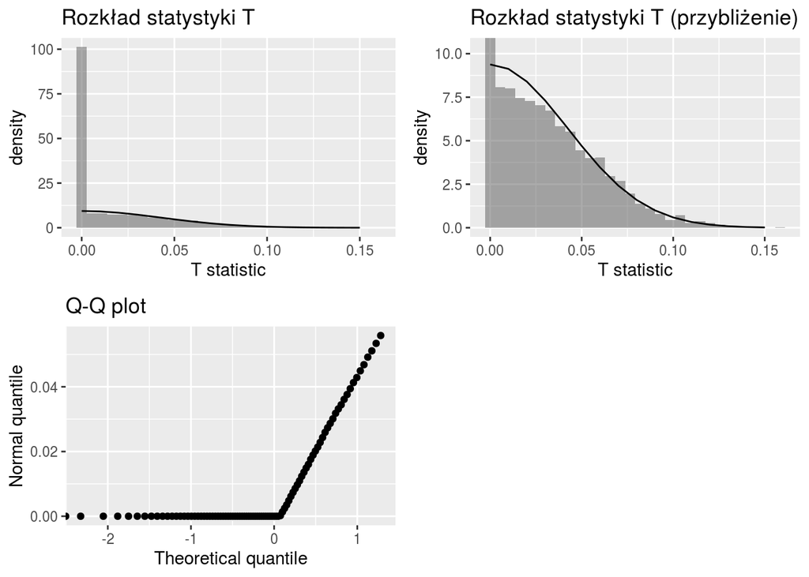

**Rozkład statystyki Chi-kwadrat**:

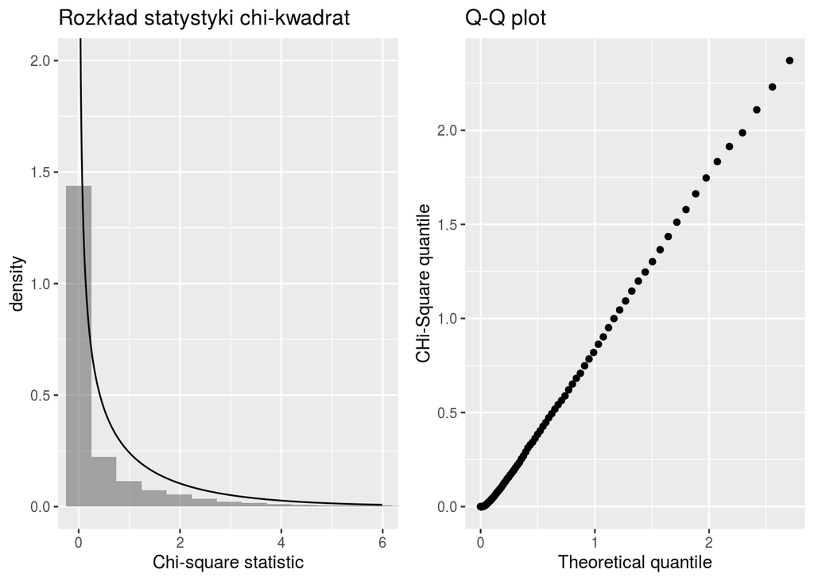

Zgodnie z oczekiwaniami znaczna część wartości statystyk ma tendencje do skupiania się w zerze. Te dane, które nie wpadły w zero mają rozkład zbliżony do rozkładów teoretycznych - rozkład standardowy normalny dla statystyki T oraz rozkład chi-kwadrat z jednym stopniem swobody dla statystyki Chi-kwadrat. Omówione zależności są szczególnie widoczne na wykresach kwantylowo-kwantylowych.